# Improving LADD Coffee’s Digital Strategy

Proposal Presentation

Mickyas Shawel

MSDM | Cal Poly Pomona

2026-08-15

# LADD Coffee: A New Local Brand

## The opportunity

LADD Coffee is a newly opened specialty café in **West Covina, California**, operating at **987 S. Glendora Ave., Unit 3**.

Public coverage describes the shop as a **Korean specialty café** with visually distinctive drinks and desserts, including cream-top beverages, matcha drinks, and pastries.

For a new café, the digital challenge is not simply *being online*.

> The goal is to turn local digital discovery into a first visit — and a first visit into repeat behavior.

### Project question

**How can LADD Coffee build a measurable digital strategy that increases local discovery, store visits, and repeat engagement?**

**Project status**

This presentation is structured as an analytics and digital-strategy **proposal**. Proposed KPIs and priority scores are planning recommendations, not historical performance results.

# Table of Contents

1. Business problem
2. Analytics objective
3. Customer and theory
4. Data readiness
5. Digital strategy
6. Measurement plan
7. Methods and next steps
8. References

# Business Problem

## New shop, limited digital history

### Business challenge

A newly opened café has to solve three problems quickly:

- Become **discoverable** when nearby consumers search for coffee.
- Give customers a reason to choose LADD over established alternatives.
- Build enough first-party measurement to understand what actually drives visits and repeat purchases.

### Why this matters

Coffee decisions are often:

- **Local**
- **Mobile**
- **Visual**
- **Time-sensitive**
- Influenced by reviews, maps, social content, and peer recommendations

A fragmented digital presence can create awareness without producing measurable customer action.

# Analytics Objective

## One primary objective

> **Determine which digital touchpoints most effectively move nearby consumers from awareness to an in-store visit, then use that evidence to prioritize LADD Coffee’s marketing effort.**

### Supporting questions

- Which channels generate the most qualified local discovery?
- Which menu items create the strongest visual/content hooks?
- Which digital actions are most associated with store-intent signals?
- Which customers can be encouraged to return?

# Importance

## Build the measurement system early

For an established retailer, analytics often means optimizing years of historical data.

For LADD Coffee, the immediate advantage is different:

1. Define useful KPIs **before** large amounts of data accumulate.
2. Establish consistent campaign tagging and channel attribution.
3. Connect discovery metrics with store-intent and purchase signals.
4. Learn which creative and products generate repeatable demand.

**Strategic advantage**

A new business can design cleaner measurement habits now instead of trying to repair fragmented data later.

# Customer Behavior Framework

## A journey-based approach

The strategy can be organized around a simple customer journey:

**Discover → Consider → Visit → Return**

### Discover & Consider

Potential customers encounter:

- Google Maps / local search
- Instagram and short-form video
- Creator or customer posts
- Reviews and recommendations
- Menu/product imagery

### Visit & Return

The digital experience should make it easy to:

- Get directions
- Understand the menu
- Identify signature items
- Save/share the shop
- Join an owned audience
- Receive a reason to return

# Current Public Signals

## What is already visible online

Public sources provide several useful early signals:

- LADD Coffee LLC was filed in California in **March 2026**.
- A June 2026 local feature described LADD as a newly opened Korean specialty café in West Covina.
- Public descriptions emphasize **cream-top drinks, matcha, desserts, and a minimalist café environment**.
- The physical location is listed as **987 S Glendora Ave., Unit 3, West Covina**.

These signals are useful for positioning, but they are **not enough to evaluate marketing performance**.

**Data limitation**

Public listings can describe the business, but they cannot answer which channels drive store visits, revenue, repeat customers, or customer lifetime value.

# Data Adequacy

## What we have vs. what we need

Table 1: Recommended measurement structure for the LADD Coffee digital customer journey

| Journey Stage | Example KPI | Recommended Data Source |
| --- | --- | --- |
| Discover | Reach / profile views / search impressions | Social insights + Google |
| Consider | Menu views / direction requests / saves | Website + business profile |
| Visit | Offer redemptions / attributed visits | POS + campaign codes |
| Return | Repeat purchase / subscriber growth | POS + email/SMS |

The key gap is **first-party behavioral and transaction data**.

# Additional Data Needed

## Build a practical data foundation

- Google Business Profile performance
- Website or landing-page analytics
- UTM-tagged campaign traffic
- Instagram/TikTok content metrics
- POS transactions by day/time/product
- Promotion or QR-code redemptions
- Email/SMS opt-ins
- Repeat-customer indicators

### Recommended unit of analysis

Where privacy and platform limitations allow, aggregate performance by:

**Date × Channel × Campaign/Content × Customer Action**

This structure supports meaningful comparisons without requiring personally identifiable customer data.

# Digital Strategy

## Prioritize channels by customer role

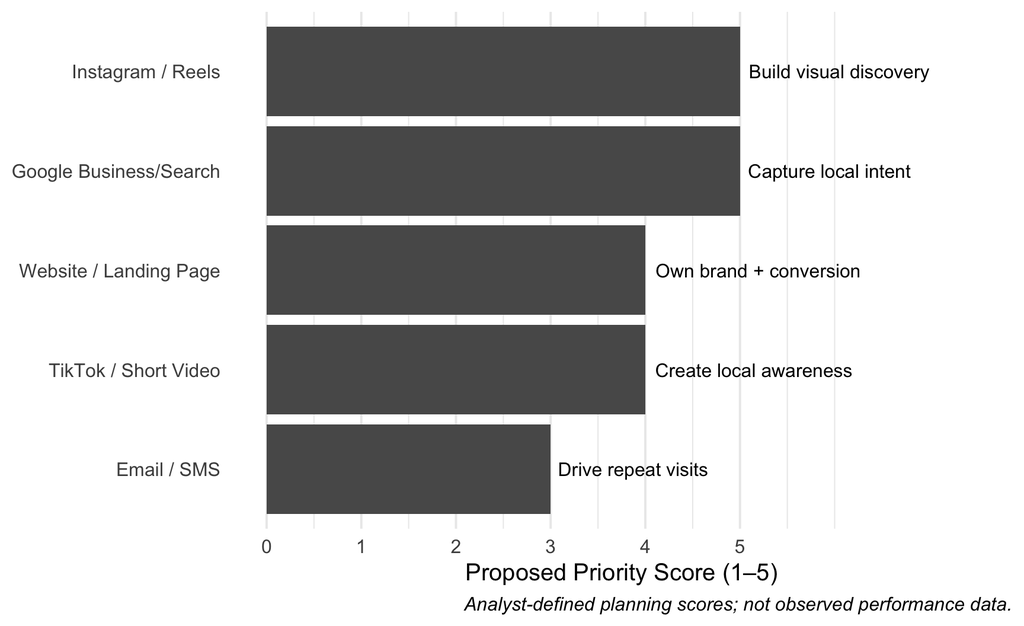

Figure 1: Proposed channel priorities for LADD Coffee’s launch-stage digital strategy

# Channel Roles

## Google: capture intent

Optimize the business profile for:

- Accurate hours and location
- Menu/product photos
- Signature-item language
- Review generation and response
- Direction and call actions

## Social: manufacture discovery

Use Instagram and TikTok to make the product visually memorable:

- Cream-top preparation
- Matcha and specialty drink builds
- Dessert pairings
- “What to order first” content
- Customer reactions and UGC
- West Covina / SGV local discovery hooks

# Owned Digital Experience

## Give discovery somewhere to convert

A lightweight website or landing page should answer the questions a first-time customer has immediately:

### Essential content

- Location and hours
- Menu / signature products
- High-quality photography
- Directions
- Social links
- FAQ

### Measurement

- GA4
- UTM conventions
- Direction-click events
- Menu-view events
- Email/SMS signup
- Offer/QR redemptions

The website should function as a **conversion and measurement layer**, not merely an online brochure.

# Content Strategy

## Make signature products the creative engine

Instead of generic “come visit us” posts, content should give audiences something specific to remember.

### Content pillars

1. **Signature drinks** — cream tops, matcha, seasonal specialties
2. **Craft/process** — preparation, ingredients, barista expertise
3. **Dessert pairing** — drinks + pastries
4. **Local identity** — West Covina and surrounding community
5. **Social proof** — reviews, reactions, UGC, creator visits

Public descriptions of LADD already emphasize visually distinctive drinks and desserts, making product-led storytelling a logical starting point.

# Measurement Framework

## KPIs by stage

| Stage | Primary Question | Example KPIs |
| --- | --- | --- |
| Discover | Are nearby consumers finding LADD? | Search impressions, reach, profile views, video views |
| Consider | Are they showing intent? | Menu views, saves, shares, direction clicks |
| Visit | Are digital efforts producing action? | Redemptions, attributed transactions, store traffic proxies |
| Return | Are we building customer value? | Repeat purchase, subscriber growth, offer response |

# Methods

## Proposed analytics workflow

1. **Instrument** the customer journey with consistent events and campaign tags.
2. **Collect** channel, content, POS, and promotion data.
3. **Wrangle** data into a common date/channel/campaign structure.
4. **Describe** performance with funnel and cohort metrics.
5. **Compare** channels and creative using normalized KPIs.
6. **Test** offers, products, and creative systematically.
7. **Recommend** budget and content changes from observed results.

# Data Wrangling

## Example structure in R

```r
campaign_data <- tibble(
  date = as.Date(c("2026-08-01", "2026-08-01", "2026-08-02")),
  channel = c("Instagram", "Google", "TikTok"),
  impressions = c(4200, 1800, 5100),
  actions = c(210, 175, 255)
) |>
  mutate(
    action_rate = actions / impressions,
    channel_group = case_when(
      channel == "Google" ~ "Intent",
      TRUE ~ "Discovery"
    )
  )

campaign_data
```

```
# A tibble: 3 × 6
  date       channel   impressions actions action_rate channel_group
  <date>     <chr>           <dbl>   <dbl>       <dbl> <chr>
1 2026-08-01 Instagram        4200     210      0.05   Discovery
2 2026-08-01 Google           1800     175      0.0972 Intent
3 2026-08-02 TikTok           5100     255      0.05   Discovery
```

**Note**

The values above are **illustrative practice data** showing how future LADD Coffee campaign data could be structured and wrangled. They are not actual business results.

# Sample Characteristics

## What a useful future sample should contain

A meaningful evaluation period should capture:

- Weekdays and weekends
- Multiple dayparts
- Several content formats
- Paid and organic traffic
- More than one promotion or creative treatment
- Product-level purchase variation
- Enough time to observe repeat behavior

The first goal is not a huge dataset. It is a **consistent dataset**.

# Measures

**Action Rate**

**Offer Redemption Rate**

**Repeat Purchase Rate**

# Analytics Methods

## Start simple, then increase sophistication

### Phase 1 — Descriptive

- Channel performance
- Content performance
- Product mix
- Day/time patterns
- Funnel conversion

### Phase 2 — Diagnostic

- Campaign comparisons
- Cohort behavior
- Promotion lift
- Creative-level differences

### Phase 3 — Predictive

Once sufficient data exist:

- Visit/purchase propensity
- Repeat-purchase classification
- Customer or product segmentation
- Demand forecasting

# Recommendations

## First 90 days

### 1. Own local search

Treat Google Business Profile and local-search accuracy as core conversion infrastructure.

### 2. Build product-led social content

Use signature beverages and desserts as the center of short-form creative.

### 3. Establish first-party measurement

Launch a simple owned landing experience with GA4, UTMs, event tracking, and opt-in capture.

### 4. Connect marketing to transactions

Use trackable offers, QR codes, POS tags, or campaign-specific promotions to create attribution signals.

### 5. Create a test-and-learn rhythm

Review performance monthly and move effort toward channels and creative that produce meaningful customer actions.

# Expected Value

## From visibility to learning

A stronger digital strategy should help LADD Coffee:

- Increase qualified local awareness
- Make signature products easier to discover
- Reduce friction between discovery and visit
- Create an owned audience for retention
- Learn which channels and content influence behavior
- Make future marketing investment more evidence-based

> The most valuable early outcome is not simply more impressions — it is a system that tells LADD Coffee what is working.

# References

- CaliNook. (2026). *LADD Coffee*. June 3, 2026.
- Los Angeles County fictitious business name publication. (2026). *LADD Coffee*, West Covina.
- Corner. (2026). *LADD Coffee — West Covina*.
- Quarto. *RevealJS Presentations*.
- CCIDM. *Effective Quarto Slides*.

# Appendix

## Research notes

This proposal uses publicly available information to establish basic business context. No private sales, POS, web analytics, advertising, or customer-level data from LADD Coffee were available during preparation.

## Reproducibility

The channel-priority chart and planning tables in this deck are generated directly from R objects contained in the QMD file.

## Future project links

**Published presentation:** https://mjshawell.github.io/IBM-6540-IBM-6300/Improving-LADD-Coffee-Digital-Strategy.html#/title-slide

**GitHub repository:** https://github.com/mjshawell/IBM-6540-IBM-6300